# Lab 4A - Clustering

### 1. Load the Data

1. Import the OS library.

```python
import os
```

2. Set the working directory.

```python
os.chdir("C:\\Workshop\\Data")
```

3. Import the pandas library as "pd".

```python
import pandas as pd
```

4. Read the Iris CSV file into a data frame called *iris*.

```python
iris = pd.read_csv("Iris.csv")
```

### 2. Explore the Data

1. Inspect the *iris* data frame using the `head` function.

```python
iris.head()
```

|  | Sepal_Length | Sepal_Width | Petal_Length | Petal_Width | Species |
| --- | --- | --- | --- | --- | --- |
| 0 | 5.1 | 3.5 | 1.4 | 0.2 | setosa |
| 1 | 4.9 | 3.0 | 1.4 | 0.2 | setosa |
| 2 | 4.7 | 3.2 | 1.3 | 0.2 | setosa |
| 3 | 4.6 | 3.1 | 1.5 | 0.2 | setosa |
| 4 | 5.0 | 3.6 | 1.4 | 0.2 | setosa |

2. Import pyplot from matplotlib as "plt".

```python
import matplotlib.pyplot as plt
```

3. Create a scatterplot matrix of the data set.

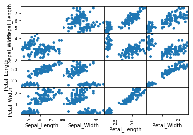

```python
pd.plotting.scatter_matrix(
    frame = iris,
    alpha = 1,
    s = 100,
    diagonal = 'none');
```

### 3. Transform the Data

1. Create a data frame of features for clustering (i.e. all columns except Species).

```python
X = iris.iloc[:, 0:4]
```

2. Inspect the features using the `head` function.

```python
X.head()
```

|  | Sepal_Length | Sepal_Width | Petal_Length | Petal_Width |
| --- | --- | --- | --- | --- |
| 0 | 5.1 | 3.5 | 1.4 | 0.2 |
| 1 | 4.9 | 3.0 | 1.4 | 0.2 |
| 2 | 4.7 | 3.2 | 1.3 | 0.2 |
| 3 | 4.6 | 3.1 | 1.5 | 0.2 |
| 4 | 5.0 | 3.6 | 1.4 | 0.2 |

3. Import the numpy library as "np".

```python
import numpy as np
```

4. Set the random number seed

```python
np.random.seed(42)
```

### 4. Cluster with k-Means

1. Import the k-means class from sklearn.

```python
from sklearn.cluster import KMeans
```

2. Create a k-means model with k = 3 and 10 random initializations.

```python
k_model = KMeans(
    n_clusters = 3,
    n_init = 10)
```

3. Fit the model to the data.

```python
k_model.fit(X)
```

```
KMeans(algorithm='auto', copy_x=True, init='k-means++', max_iter=300,
    n_clusters=3, n_init=10, n_jobs=1, precompute_distances='auto',
    random_state=None, tol=0.0001, verbose=0)
```

4. Create a palette with three colors for each of the tree clusters.

```python
palette = {0:'#fb8072', 1:'#80b1d3', 2:'#b3de69'}
```

5. Map the colors to each of the clusters.

```python
k_colors = pd.Series(k_model.labels_) \
    .apply(lambda x:palette[x])
```

6. Plot a scatterplot of petal width (*y*) vs. petal length (*x*) colored by the clusters.  
Superimpose the centroids of each cluster as X's on the scatterplot.

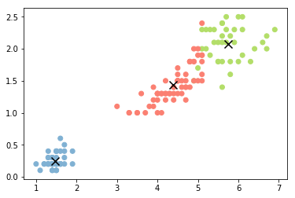

```python
plt.scatter(
    x = iris.Petal_Length,
    y = iris.Petal_Width,
    color = k_colors)
plt.scatter(
    x = k_model.cluster_centers_[:,2],
    y = k_model.cluster_centers_[:,3],
    marker = 'x',
    color = "black",
    s = 100)
plt.xlabel = "Petal Length"
plt.ylabel = "Petal Width"
plt.show()
```

7. Question: How do you interpret this plot?

### 5. Cluster with Hierachical Clustering

1. Import the agglomerative clustering class from sklearn

```python
from sklearn.cluster import AgglomerativeClustering
```

2. Create a hierachical cluster model with three clusters.

```python
h_model = AgglomerativeClustering(
    n_clusters = 3)
```

3. Fit the model to the data.

```python
h_model.fit(X)
```

```
AgglomerativeClustering(affinity='euclidean', compute_full_tree='auto',
            connectivity=None, linkage='ward', memory=None, n_clusters=3,
            pooling_func=<function mean at 0x000001A44A2910D0>)
```

4. Import the dendrogram function from scipy.

```python
from scipy.cluster.hierarchy import dendrogram
```

5. Plot the dendrogram

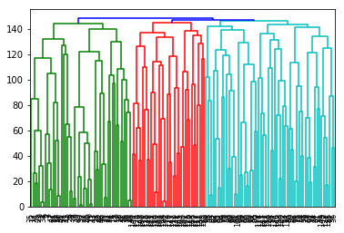

```python
children = h_model.children_

distance = np.arange(children.shape[0])

observations = np.arange(2, children.shape[0] + 2)

linkage_matrix = np.column_stack([children, distance, observations]).astype(float)

dendrogram(
    Z = linkage_matrix,
    leaf_font_size = 8,
    color_threshold = 147);
```

6. Question: How do you interpret this dendrogram?

7. Map the previous three colors to each cluster.

```python
h_colors = pd.Series(h_model.labels_) \
    .apply(lambda x:palette[x])
```

8. Plot a scatterplot of petal width (*y*) vs. petal length (*x*) colored by cluster.

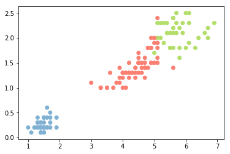

```python
plt.scatter(
    x = iris.Petal_Length,
    y = iris.Petal_Width,
    color = h_colors)
plt.xlabel = "Petal Length"
plt.ylabel = "Petal Width"
plt.show()
```

9. Question: What is the difference between these two methods of clustering?